# Risk Factor Analysis

## Outcome Variable

**Outcome Variable:** sstunted

## Predictor Variables

**Intervention Variable:** birthlen

**Adjustment Set:**

- arm
- sex
- W_mage
- meducyrs
- feducyrs
- vagbrth
- single
- brthmon
- W_parity
- delta_W_mage
- delta_meducyrs
- delta_feducyrs
- delta_vagbrth
- delta_single
- delta_brthmon
- delta_W_parity

## Stratifying Variables

The analysis was stratified on these variable(s):

- agecat
- studyid
- country

## Data Summary

| agecat | studyid | country | birthlen | sstunted | n_cell | n |
| --- | --- | --- | --- | --- | --- | --- |
| Birth | ki0047075b-MAL-ED | BANGLADESH | >=50 cm | 0 | 39 | 231 |
| Birth | ki0047075b-MAL-ED | BANGLADESH | >=50 cm | 1 | 0 | 231 |
| Birth | ki0047075b-MAL-ED | BANGLADESH | <48 cm | 0 | 104 | 231 |
| Birth | ki0047075b-MAL-ED | BANGLADESH | <48 cm | 1 | 9 | 231 |
| Birth | ki0047075b-MAL-ED | BANGLADESH | [48-50) cm | 0 | 79 | 231 |
| Birth | ki0047075b-MAL-ED | BANGLADESH | [48-50) cm | 1 | 0 | 231 |
| Birth | ki0047075b-MAL-ED | BRAZIL | >=50 cm | 0 | 30 | 65 |
| Birth | ki0047075b-MAL-ED | BRAZIL | >=50 cm | 1 | 0 | 65 |
| Birth | ki0047075b-MAL-ED | BRAZIL | <48 cm | 0 | 14 | 65 |
| Birth | ki0047075b-MAL-ED | BRAZIL | <48 cm | 1 | 3 | 65 |
| Birth | ki0047075b-MAL-ED | BRAZIL | [48-50) cm | 0 | 18 | 65 |
| Birth | ki0047075b-MAL-ED | BRAZIL | [48-50) cm | 1 | 0 | 65 |
| Birth | ki0047075b-MAL-ED | INDIA | >=50 cm | 0 | 9 | 47 |
| Birth | ki0047075b-MAL-ED | INDIA | >=50 cm | 1 | 0 | 47 |
| Birth | ki0047075b-MAL-ED | INDIA | <48 cm | 0 | 18 | 47 |
| Birth | ki0047075b-MAL-ED | INDIA | <48 cm | 1 | 2 | 47 |
| Birth | ki0047075b-MAL-ED | INDIA | [48-50) cm | 0 | 18 | 47 |
| Birth | ki0047075b-MAL-ED | INDIA | [48-50) cm | 1 | 0 | 47 |
| Birth | ki0047075b-MAL-ED | NEPAL | >=50 cm | 0 | 8 | 27 |
| Birth | ki0047075b-MAL-ED | NEPAL | >=50 cm | 1 | 0 | 27 |
| Birth | ki0047075b-MAL-ED | NEPAL | <48 cm | 0 | 11 | 27 |
| Birth | ki0047075b-MAL-ED | NEPAL | <48 cm | 1 | 1 | 27 |
| Birth | ki0047075b-MAL-ED | NEPAL | [48-50) cm | 0 | 7 | 27 |
| Birth | ki0047075b-MAL-ED | NEPAL | [48-50) cm | 1 | 0 | 27 |
| Birth | ki0047075b-MAL-ED | PERU | >=50 cm | 0 | 52 | 233 |
| Birth | ki0047075b-MAL-ED | PERU | >=50 cm | 1 | 0 | 233 |
| Birth | ki0047075b-MAL-ED | PERU | <48 cm | 0 | 84 | 233 |
| Birth | ki0047075b-MAL-ED | PERU | <48 cm | 1 | 4 | 233 |
| Birth | ki0047075b-MAL-ED | PERU | [48-50) cm | 0 | 93 | 233 |
| Birth | ki0047075b-MAL-ED | PERU | [48-50) cm | 1 | 0 | 233 |

[output cut: 426 more lines]

The following strata were considered:

- agecat: 24 months, studyid: ki0047075b-MAL-ED, country: BANGLADESH
- agecat: 24 months, studyid: ki0047075b-MAL-ED, country: BRAZIL
- agecat: 24 months, studyid: ki0047075b-MAL-ED, country: INDIA
- agecat: 24 months, studyid: ki0047075b-MAL-ED, country: NEPAL
- agecat: 24 months, studyid: ki0047075b-MAL-ED, country: PERU
- agecat: 24 months, studyid: ki0047075b-MAL-ED, country: SOUTH AFRICA
- agecat: 24 months, studyid: ki0047075b-MAL-ED, country: TANZANIA, UNITED REPUBLIC OF
- agecat: 24 months, studyid: ki1000108-CMC-V-BCS-2002, country: INDIA
- agecat: 24 months, studyid: ki1000108-IRC, country: INDIA
- agecat: 24 months, studyid: ki1000109-EE, country: PAKISTAN
- agecat: 24 months, studyid: ki1017093-NIH-Birth, country: BANGLADESH
- agecat: 24 months, studyid: ki1017093b-PROVIDE, country: BANGLADESH
- agecat: 24 months, studyid: ki1017093c-NIH-Crypto, country: BANGLADESH
- agecat: 24 months, studyid: ki1101329-Keneba, country: GAMBIA
- agecat: 24 months, studyid: ki1113344-GMS-Nepal, country: NEPAL
- agecat: 24 months, studyid: ki1114097-CMIN, country: BANGLADESH
- agecat: 24 months, studyid: ki1114097-CONTENT, country: PERU
- agecat: 24 months, studyid: ki1119695-PROBIT, country: BELARUS
- agecat: 24 months, studyid: ki1126311-ZVITAMBO, country: ZIMBABWE
- agecat: 24 months, studyid: ki1135781-COHORTS, country: GUATEMALA
- agecat: 24 months, studyid: ki1135781-COHORTS, country: INDIA
- agecat: 24 months, studyid: ki1135781-COHORTS, country: PHILIPPINES
- agecat: 24 months, studyid: kiGH5241-JiVitA-3, country: BANGLADESH
- agecat: 24 months, studyid: kiGH5241-JiVitA-4, country: BANGLADESH
- agecat: 6 months, studyid: ki0047075b-MAL-ED, country: BANGLADESH
- agecat: 6 months, studyid: ki0047075b-MAL-ED, country: BRAZIL
- agecat: 6 months, studyid: ki0047075b-MAL-ED, country: INDIA
- agecat: 6 months, studyid: ki0047075b-MAL-ED, country: NEPAL
- agecat: 6 months, studyid: ki0047075b-MAL-ED, country: PERU
- agecat: 6 months, studyid: ki0047075b-MAL-ED, country: SOUTH AFRICA
- agecat: 6 months, studyid: ki0047075b-MAL-ED, country: TANZANIA, UNITED REPUBLIC OF
- agecat: 6 months, studyid: ki1000108-CMC-V-BCS-2002, country: INDIA
- agecat: 6 months, studyid: ki1000108-IRC, country: INDIA
- agecat: 6 months, studyid: ki1000109-EE, country: PAKISTAN
- agecat: 6 months, studyid: ki1000109-ResPak, country: PAKISTAN
- agecat: 6 months, studyid: ki1000304b-SAS-CompFeed, country: INDIA
- agecat: 6 months, studyid: ki1017093-NIH-Birth, country: BANGLADESH
- agecat: 6 months, studyid: ki1017093b-PROVIDE, country: BANGLADESH
- agecat: 6 months, studyid: ki1017093c-NIH-Crypto, country: BANGLADESH
- agecat: 6 months, studyid: ki1101329-Keneba, country: GAMBIA
- agecat: 6 months, studyid: ki1113344-GMS-Nepal, country: NEPAL
- agecat: 6 months, studyid: ki1114097-CMIN, country: BANGLADESH
- agecat: 6 months, studyid: ki1114097-CONTENT, country: PERU
- agecat: 6 months, studyid: ki1119695-PROBIT, country: BELARUS
- agecat: 6 months, studyid: ki1126311-ZVITAMBO, country: ZIMBABWE
- agecat: 6 months, studyid: ki1135781-COHORTS, country: GUATEMALA
- agecat: 6 months, studyid: ki1135781-COHORTS, country: INDIA
- agecat: 6 months, studyid: ki1135781-COHORTS, country: PHILIPPINES
- agecat: 6 months, studyid: kiGH5241-JiVitA-3, country: BANGLADESH
- agecat: 6 months, studyid: kiGH5241-JiVitA-4, country: BANGLADESH
- agecat: Birth, studyid: ki0047075b-MAL-ED, country: BANGLADESH
- agecat: Birth, studyid: ki0047075b-MAL-ED, country: BRAZIL
- agecat: Birth, studyid: ki0047075b-MAL-ED, country: INDIA
- agecat: Birth, studyid: ki0047075b-MAL-ED, country: NEPAL
- agecat: Birth, studyid: ki0047075b-MAL-ED, country: PERU
- agecat: Birth, studyid: ki0047075b-MAL-ED, country: SOUTH AFRICA
- agecat: Birth, studyid: ki0047075b-MAL-ED, country: TANZANIA, UNITED REPUBLIC OF
- agecat: Birth, studyid: ki1000108-CMC-V-BCS-2002, country: INDIA
- agecat: Birth, studyid: ki1000108-IRC, country: INDIA
- agecat: Birth, studyid: ki1000109-EE, country: PAKISTAN
- agecat: Birth, studyid: ki1000109-ResPak, country: PAKISTAN
- agecat: Birth, studyid: ki1000304b-SAS-CompFeed, country: INDIA
- agecat: Birth, studyid: ki1017093-NIH-Birth, country: BANGLADESH
- agecat: Birth, studyid: ki1017093b-PROVIDE, country: BANGLADESH
- agecat: Birth, studyid: ki1017093c-NIH-Crypto, country: BANGLADESH
- agecat: Birth, studyid: ki1101329-Keneba, country: GAMBIA
- agecat: Birth, studyid: ki1113344-GMS-Nepal, country: NEPAL
- agecat: Birth, studyid: ki1114097-CMIN, country: BANGLADESH
- agecat: Birth, studyid: ki1114097-CONTENT, country: PERU
- agecat: Birth, studyid: ki1119695-PROBIT, country: BELARUS
- agecat: Birth, studyid: ki1126311-ZVITAMBO, country: ZIMBABWE
- agecat: Birth, studyid: ki1135781-COHORTS, country: GUATEMALA
- agecat: Birth, studyid: ki1135781-COHORTS, country: INDIA
- agecat: Birth, studyid: ki1135781-COHORTS, country: PHILIPPINES
- agecat: Birth, studyid: kiGH5241-JiVitA-3, country: BANGLADESH
- agecat: Birth, studyid: kiGH5241-JiVitA-4, country: BANGLADESH

### Dropped Strata

Some strata were dropped due to rare outcomes:

- agecat: Birth, studyid: ki0047075b-MAL-ED, country: BANGLADESH
- agecat: Birth, studyid: ki0047075b-MAL-ED, country: BRAZIL
- agecat: Birth, studyid: ki0047075b-MAL-ED, country: INDIA
- agecat: Birth, studyid: ki0047075b-MAL-ED, country: NEPAL
- agecat: Birth, studyid: ki0047075b-MAL-ED, country: PERU
- agecat: Birth, studyid: ki0047075b-MAL-ED, country: SOUTH AFRICA
- agecat: Birth, studyid: ki0047075b-MAL-ED, country: TANZANIA, UNITED REPUBLIC OF
- agecat: Birth, studyid: ki1000108-CMC-V-BCS-2002, country: INDIA
- agecat: Birth, studyid: ki1000108-IRC, country: INDIA
- agecat: Birth, studyid: ki1000109-EE, country: PAKISTAN
- agecat: Birth, studyid: ki1000109-ResPak, country: PAKISTAN
- agecat: Birth, studyid: ki1000304b-SAS-CompFeed, country: INDIA
- agecat: Birth, studyid: ki1017093-NIH-Birth, country: BANGLADESH
- agecat: Birth, studyid: ki1017093b-PROVIDE, country: BANGLADESH
- agecat: Birth, studyid: ki1017093c-NIH-Crypto, country: BANGLADESH
- agecat: Birth, studyid: ki1101329-Keneba, country: GAMBIA
- agecat: Birth, studyid: ki1113344-GMS-Nepal, country: NEPAL
- agecat: Birth, studyid: ki1114097-CMIN, country: BANGLADESH
- agecat: Birth, studyid: ki1114097-CONTENT, country: PERU
- agecat: Birth, studyid: ki1119695-PROBIT, country: BELARUS
- agecat: Birth, studyid: ki1126311-ZVITAMBO, country: ZIMBABWE
- agecat: Birth, studyid: ki1135781-COHORTS, country: GUATEMALA
- agecat: Birth, studyid: ki1135781-COHORTS, country: INDIA
- agecat: Birth, studyid: ki1135781-COHORTS, country: PHILIPPINES
- agecat: Birth, studyid: kiGH5241-JiVitA-3, country: BANGLADESH
- agecat: Birth, studyid: kiGH5241-JiVitA-4, country: BANGLADESH
- agecat: 6 months, studyid: ki0047075b-MAL-ED, country: BANGLADESH
- agecat: 6 months, studyid: ki0047075b-MAL-ED, country: BRAZIL
- agecat: 6 months, studyid: ki0047075b-MAL-ED, country: INDIA
- agecat: 6 months, studyid: ki0047075b-MAL-ED, country: NEPAL
- agecat: 6 months, studyid: ki0047075b-MAL-ED, country: PERU
- agecat: 6 months, studyid: ki0047075b-MAL-ED, country: SOUTH AFRICA
- agecat: 6 months, studyid: ki0047075b-MAL-ED, country: TANZANIA, UNITED REPUBLIC OF
- agecat: 6 months, studyid: ki1000108-CMC-V-BCS-2002, country: INDIA
- agecat: 6 months, studyid: ki1000108-IRC, country: INDIA
- agecat: 6 months, studyid: ki1000109-EE, country: PAKISTAN
- agecat: 6 months, studyid: ki1000109-ResPak, country: PAKISTAN
- agecat: 6 months, studyid: ki1017093-NIH-Birth, country: BANGLADESH
- agecat: 6 months, studyid: ki1017093b-PROVIDE, country: BANGLADESH
- agecat: 6 months, studyid: ki1017093c-NIH-Crypto, country: BANGLADESH
- agecat: 6 months, studyid: ki1113344-GMS-Nepal, country: NEPAL
- agecat: 6 months, studyid: ki1114097-CMIN, country: BANGLADESH
- agecat: 6 months, studyid: ki1114097-CONTENT, country: PERU
- agecat: 6 months, studyid: kiGH5241-JiVitA-3, country: BANGLADESH
- agecat: 24 months, studyid: ki0047075b-MAL-ED, country: BANGLADESH
- agecat: 24 months, studyid: ki0047075b-MAL-ED, country: BRAZIL
- agecat: 24 months, studyid: ki0047075b-MAL-ED, country: INDIA
- agecat: 24 months, studyid: ki0047075b-MAL-ED, country: NEPAL
- agecat: 24 months, studyid: ki0047075b-MAL-ED, country: PERU
- agecat: 24 months, studyid: ki0047075b-MAL-ED, country: SOUTH AFRICA
- agecat: 24 months, studyid: ki0047075b-MAL-ED, country: TANZANIA, UNITED REPUBLIC OF
- agecat: 24 months, studyid: ki1000108-CMC-V-BCS-2002, country: INDIA
- agecat: 24 months, studyid: ki1000109-EE, country: PAKISTAN
- agecat: 24 months, studyid: ki1017093b-PROVIDE, country: BANGLADESH
- agecat: 24 months, studyid: ki1017093c-NIH-Crypto, country: BANGLADESH
- agecat: 24 months, studyid: ki1113344-GMS-Nepal, country: NEPAL
- agecat: 24 months, studyid: ki1114097-CMIN, country: BANGLADESH
- agecat: 24 months, studyid: ki1114097-CONTENT, country: PERU
- agecat: 24 months, studyid: ki1119695-PROBIT, country: BELARUS

## Methods Detail

We’re interested in the causal parameters $E[Y_a]$ for all values of $a \in \mathcal{A}$. These parameters represent the mean outcome if, possibly contrary to fact, we intervened to set all units to have $A=a$. Under the randomization and positivity assumptions, these are identified by the statistical parameters $\psi_a=E_W[E_{Y|A,W}(Y|A=a,W)]$. In addition, we’re interested in the mean of $Y$, $E[Y]$ under no intervention (the observed mean). We will estimate these parameters by using SuperLearner to fit the relevant likelihood factors – $E_{Y|A,W}(Y|A=a,W)$ and $p(A=a|W)$, and then updating our likelihood fit using a joint TMLE.

For unadjusted analyses ($W=\{\}$), initial likelihoods were estimated using Lrnr_glm to estimate the simple $E(Y|A)$ and Lrnr_mean to estimate $p(A)$. For adjusted analyses, a small library containing Lrnr_glmnet, Lrnr_xgboost, and Lrnr_mean was used.

Having estimated these parameters, we will then use the delta method to estimate relative risks and attributable risks relative to a prespecified baseline level of $A$.

# Results Detail

## Results Plots

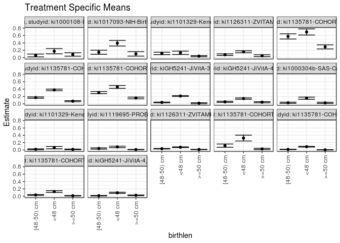

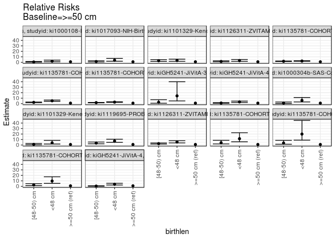

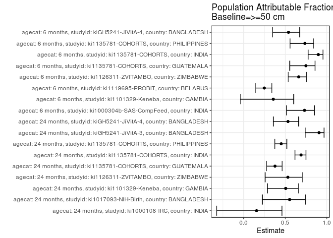

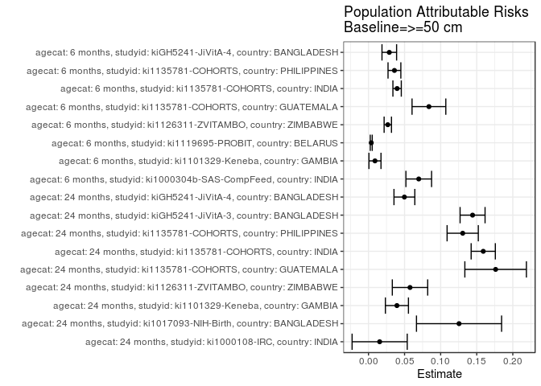

## Results Table

### Parameter: TSM

| agecat | studyid | country | intervention_level | baseline_level | estimate | ci_lower | ci_upper |
| --- | --- | --- | --- | --- | --- | --- | --- |
| 6 months | ki1000304b-SAS-CompFeed | INDIA | >=50 cm | NA | 0.0255102 | 0.0084713 | 0.0425492 |
| 6 months | ki1000304b-SAS-CompFeed | INDIA | <48 cm | NA | 0.1537377 | 0.1251875 | 0.1822879 |
| 6 months | ki1000304b-SAS-CompFeed | INDIA | [48-50) cm | NA | 0.0286396 | 0.0129545 | 0.0443247 |
| 6 months | ki1101329-Keneba | GAMBIA | >=50 cm | NA | 0.0162482 | 0.0067211 | 0.0257752 |
| 6 months | ki1101329-Keneba | GAMBIA | <48 cm | NA | 0.0641026 | 0.0327081 | 0.0954970 |
| 6 months | ki1101329-Keneba | GAMBIA | [48-50) cm | NA | 0.0183486 | 0.0057464 | 0.0309508 |
| 6 months | ki1119695-PROBIT | BELARUS | >=50 cm | NA | 0.0115919 | 0.0065924 | 0.0165915 |
| 6 months | ki1119695-PROBIT | BELARUS | <48 cm | NA | 0.0843304 | 0.0637329 | 0.1049278 |
| 6 months | ki1119695-PROBIT | BELARUS | [48-50) cm | NA | 0.0412032 | 0.0255108 | 0.0568956 |
| 6 months | ki1126311-ZVITAMBO | ZIMBABWE | >=50 cm | NA | 0.0136846 | 0.0090916 | 0.0182776 |
| 6 months | ki1126311-ZVITAMBO | ZIMBABWE | <48 cm | NA | 0.0754000 | 0.0655330 | 0.0852670 |
| 6 months | ki1126311-ZVITAMBO | ZIMBABWE | [48-50) cm | NA | 0.0348668 | 0.0286444 | 0.0410893 |
| 6 months | ki1135781-COHORTS | GUATEMALA | >=50 cm | NA | 0.0281561 | 0.0107702 | 0.0455420 |
| 6 months | ki1135781-COHORTS | GUATEMALA | <48 cm | NA | 0.3247488 | 0.2450762 | 0.4044214 |
| 6 months | ki1135781-COHORTS | GUATEMALA | [48-50) cm | NA | 0.1178621 | 0.0733491 | 0.1623750 |
| 6 months | ki1135781-COHORTS | INDIA | >=50 cm | NA | 0.0045113 | 0.0009094 | 0.0081131 |
| 6 months | ki1135781-COHORTS | INDIA | <48 cm | NA | 0.0901186 | 0.0789596 | 0.1012775 |
| 6 months | ki1135781-COHORTS | INDIA | [48-50) cm | NA | 0.0162637 | 0.0110657 | 0.0214618 |
| 6 months | ki1135781-COHORTS | PHILIPPINES | >=50 cm | NA | 0.0129031 | 0.0058942 | 0.0199120 |
| 6 months | ki1135781-COHORTS | PHILIPPINES | <48 cm | NA | 0.1265095 | 0.1014334 | 0.1515856 |
| 6 months | ki1135781-COHORTS | PHILIPPINES | [48-50) cm | NA | 0.0336696 | 0.0226501 | 0.0446890 |
| 6 months | kiGH5241-JiVitA-4 | BANGLADESH | >=50 cm | NA | 0.0246465 | 0.0157105 | 0.0335826 |
| 6 months | kiGH5241-JiVitA-4 | BANGLADESH | <48 cm | NA | 0.0932553 | 0.0771589 | 0.1093518 |
| 6 months | kiGH5241-JiVitA-4 | BANGLADESH | [48-50) cm | NA | 0.0137974 | 0.0063599 | 0.0212349 |
| 24 months | ki1000108-IRC | INDIA | >=50 cm | NA | 0.0845070 | 0.0386997 | 0.1303144 |
| 24 months | ki1000108-IRC | INDIA | <48 cm | NA | 0.1727273 | 0.1019956 | 0.2434590 |
| 24 months | ki1000108-IRC | INDIA | [48-50) cm | NA | 0.0579710 | 0.0189316 | 0.0970105 |
| 24 months | ki1017093-NIH-Birth | BANGLADESH | >=50 cm | NA | 0.1015595 | 0.0419831 | 0.1611358 |
| 24 months | ki1017093-NIH-Birth | BANGLADESH | <48 cm | NA | 0.3910659 | 0.3152192 | 0.4669125 |
| 24 months | ki1017093-NIH-Birth | BANGLADESH | [48-50) cm | NA | 0.1453254 | 0.0899045 | 0.2007464 |
| 24 months | ki1101329-Keneba | GAMBIA | >=50 cm | NA | 0.0385358 | 0.0219804 | 0.0550913 |
| 24 months | ki1101329-Keneba | GAMBIA | <48 cm | NA | 0.1299325 | 0.0841606 | 0.1757044 |
| 24 months | ki1101329-Keneba | GAMBIA | [48-50) cm | NA | 0.1132249 | 0.0799407 | 0.1465091 |
| 24 months | ki1126311-ZVITAMBO | ZIMBABWE | >=50 cm | NA | 0.0506738 | 0.0261196 | 0.0752279 |
| 24 months | ki1126311-ZVITAMBO | ZIMBABWE | <48 cm | NA | 0.1574889 | 0.1306703 | 0.1843076 |
| 24 months | ki1126311-ZVITAMBO | ZIMBABWE | [48-50) cm | NA | 0.0789573 | 0.0569770 | 0.1009375 |
| 24 months | ki1135781-COHORTS | GUATEMALA | >=50 cm | NA | 0.2916647 | 0.2365394 | 0.3467901 |
| 24 months | ki1135781-COHORTS | GUATEMALA | <48 cm | NA | 0.6965135 | 0.6138304 | 0.7791966 |
| 24 months | ki1135781-COHORTS | GUATEMALA | [48-50) cm | NA | 0.5756315 | 0.5045653 | 0.6466978 |
| 24 months | ki1135781-COHORTS | INDIA | >=50 cm | NA | 0.0713027 | 0.0555749 | 0.0870305 |
| 24 months | ki1135781-COHORTS | INDIA | <48 cm | NA | 0.3772041 | 0.3558528 | 0.3985554 |
| 24 months | ki1135781-COHORTS | INDIA | [48-50) cm | NA | 0.1693339 | 0.1518700 | 0.1867978 |
| 24 months | ki1135781-COHORTS | PHILIPPINES | >=50 cm | NA | 0.1585309 | 0.1345577 | 0.1825041 |
| 24 months | ki1135781-COHORTS | PHILIPPINES | <48 cm | NA | 0.4582560 | 0.4193258 | 0.4971862 |
| 24 months | ki1135781-COHORTS | PHILIPPINES | [48-50) cm | NA | 0.3047827 | 0.2757486 | 0.3338168 |
| 24 months | kiGH5241-JiVitA-3 | BANGLADESH | >=50 cm | NA | 0.0148515 | -0.0004421 | 0.0301450 |
| 24 months | kiGH5241-JiVitA-3 | BANGLADESH | <48 cm | NA | 0.2117624 | 0.1987696 | 0.2247552 |
| 24 months | kiGH5241-JiVitA-3 | BANGLADESH | [48-50) cm | NA | 0.0373614 | 0.0276804 | 0.0470423 |
| 24 months | kiGH5241-JiVitA-4 | BANGLADESH | >=50 cm | NA | 0.0435369 | 0.0282652 | 0.0588085 |
| 24 months | kiGH5241-JiVitA-4 | BANGLADESH | <48 cm | NA | 0.1428626 | 0.1251021 | 0.1606230 |
| 24 months | kiGH5241-JiVitA-4 | BANGLADESH | [48-50) cm | NA | 0.0530035 | 0.0368874 | 0.0691196 |

### Parameter: E(Y)

| agecat | studyid | country | intervention_level | baseline_level | estimate | ci_lower | ci_upper |
| --- | --- | --- | --- | --- | --- | --- | --- |
| 6 months | ki1000304b-SAS-CompFeed | INDIA | NA | NA | 0.0951662 | 0.0766361 | 0.1136962 |
| 6 months | ki1101329-Keneba | GAMBIA | NA | NA | 0.0252413 | 0.0168616 | 0.0336210 |
| 6 months | ki1119695-PROBIT | BELARUS | NA | NA | 0.0154178 | 0.0100323 | 0.0208033 |
| 6 months | ki1126311-ZVITAMBO | ZIMBABWE | NA | NA | 0.0404570 | 0.0362870 | 0.0446270 |
| 6 months | ki1135781-COHORTS | GUATEMALA | NA | NA | 0.1119186 | 0.0883438 | 0.1354934 |
| 6 months | ki1135781-COHORTS | INDIA | NA | NA | 0.0441728 | 0.0390306 | 0.0493149 |
| 6 months | ki1135781-COHORTS | PHILIPPINES | NA | NA | 0.0488708 | 0.0407385 | 0.0570030 |
| 6 months | kiGH5241-JiVitA-4 | BANGLADESH | NA | NA | 0.0534826 | 0.0450763 | 0.0618888 |
| 24 months | ki1000108-IRC | INDIA | NA | NA | 0.1000000 | 0.0701878 | 0.1298122 |
| 24 months | ki1017093-NIH-Birth | BANGLADESH | NA | NA | 0.2270531 | 0.1866503 | 0.2674560 |
| 24 months | ki1101329-Keneba | GAMBIA | NA | NA | 0.0779343 | 0.0618270 | 0.0940416 |
| 24 months | ki1126311-ZVITAMBO | ZIMBABWE | NA | NA | 0.1082090 | 0.0930209 | 0.1233971 |
| 24 months | ki1135781-COHORTS | GUATEMALA | NA | NA | 0.4678571 | 0.4264941 | 0.5092202 |
| 24 months | ki1135781-COHORTS | INDIA | NA | NA | 0.2303489 | 0.2183836 | 0.2423141 |
| 24 months | ki1135781-COHORTS | PHILIPPINES | NA | NA | 0.2891073 | 0.2711229 | 0.3070917 |
| 24 months | kiGH5241-JiVitA-3 | BANGLADESH | NA | NA | 0.1591036 | 0.1492688 | 0.1689383 |
| 24 months | kiGH5241-JiVitA-4 | BANGLADESH | NA | NA | 0.0933032 | 0.0829251 | 0.1036813 |

### Parameter: RR

| agecat | studyid | country | intervention_level | baseline_level | estimate | ci_lower | ci_upper |
| --- | --- | --- | --- | --- | --- | --- | --- |
| 6 months | ki1000304b-SAS-CompFeed | INDIA | >=50 cm | >=50 cm | 1.0000000 | 1.0000000 | 1.000000 |
| 6 months | ki1000304b-SAS-CompFeed | INDIA | <48 cm | >=50 cm | 6.0265162 | 3.2342085 | 11.229609 |
| 6 months | ki1000304b-SAS-CompFeed | INDIA | [48-50) cm | >=50 cm | 1.1226730 | 0.4128721 | 3.052748 |
| 6 months | ki1101329-Keneba | GAMBIA | >=50 cm | >=50 cm | 1.0000000 | 1.0000000 | 1.000000 |
| 6 months | ki1101329-Keneba | GAMBIA | <48 cm | >=50 cm | 3.9452214 | 1.8377214 | 8.469604 |
| 6 months | ki1101329-Keneba | GAMBIA | [48-50) cm | >=50 cm | 1.1292744 | 0.4577236 | 2.786093 |
| 6 months | ki1119695-PROBIT | BELARUS | >=50 cm | >=50 cm | 1.0000000 | 1.0000000 | 1.000000 |
| 6 months | ki1119695-PROBIT | BELARUS | <48 cm | >=50 cm | 7.2749307 | 4.9786359 | 10.630345 |
| 6 months | ki1119695-PROBIT | BELARUS | [48-50) cm | >=50 cm | 3.5544778 | 2.3313898 | 5.419219 |
| 6 months | ki1126311-ZVITAMBO | ZIMBABWE | >=50 cm | >=50 cm | 1.0000000 | 1.0000000 | 1.000000 |
| 6 months | ki1126311-ZVITAMBO | ZIMBABWE | <48 cm | >=50 cm | 5.5098422 | 3.8435305 | 7.898561 |
| 6 months | ki1126311-ZVITAMBO | ZIMBABWE | [48-50) cm | >=50 cm | 2.5478864 | 1.7423846 | 3.725770 |
| 6 months | ki1135781-COHORTS | GUATEMALA | >=50 cm | >=50 cm | 1.0000000 | 1.0000000 | 1.000000 |
| 6 months | ki1135781-COHORTS | GUATEMALA | <48 cm | >=50 cm | 11.5338821 | 5.9364414 | 22.409122 |
| 6 months | ki1135781-COHORTS | GUATEMALA | [48-50) cm | >=50 cm | 4.1860268 | 2.0317446 | 8.624519 |
| 6 months | ki1135781-COHORTS | INDIA | >=50 cm | >=50 cm | 1.0000000 | 1.0000000 | 1.000000 |
| 6 months | ki1135781-COHORTS | INDIA | <48 cm | >=50 cm | 19.9762846 | 8.9048026 | 44.813115 |
| 6 months | ki1135781-COHORTS | INDIA | [48-50) cm | >=50 cm | 3.6051282 | 1.5255447 | 8.519547 |
| 6 months | ki1135781-COHORTS | PHILIPPINES | >=50 cm | >=50 cm | 1.0000000 | 1.0000000 | 1.000000 |
| 6 months | ki1135781-COHORTS | PHILIPPINES | <48 cm | >=50 cm | 9.8045759 | 5.5026453 | 17.469726 |
| 6 months | ki1135781-COHORTS | PHILIPPINES | [48-50) cm | >=50 cm | 2.6094161 | 1.3849829 | 4.916344 |
| 6 months | kiGH5241-JiVitA-4 | BANGLADESH | >=50 cm | >=50 cm | 1.0000000 | 1.0000000 | 1.000000 |
| 6 months | kiGH5241-JiVitA-4 | BANGLADESH | <48 cm | >=50 cm | 3.7837105 | 2.5387962 | 5.639076 |
| 6 months | kiGH5241-JiVitA-4 | BANGLADESH | [48-50) cm | >=50 cm | 0.5598118 | 0.2906254 | 1.078327 |
| 24 months | ki1000108-IRC | INDIA | >=50 cm | >=50 cm | 1.0000000 | 1.0000000 | 1.000000 |
| 24 months | ki1000108-IRC | INDIA | <48 cm | >=50 cm | 2.0439394 | 1.0361710 | 4.031852 |
| 24 months | ki1000108-IRC | INDIA | [48-50) cm | >=50 cm | 0.6859903 | 0.2889866 | 1.628389 |
| 24 months | ki1017093-NIH-Birth | BANGLADESH | >=50 cm | >=50 cm | 1.0000000 | 1.0000000 | 1.000000 |
| 24 months | ki1017093-NIH-Birth | BANGLADESH | <48 cm | >=50 cm | 3.8506103 | 2.0748572 | 7.146130 |
| 24 months | ki1017093-NIH-Birth | BANGLADESH | [48-50) cm | >=50 cm | 1.4309394 | 0.7107142 | 2.881028 |
| 24 months | ki1101329-Keneba | GAMBIA | >=50 cm | >=50 cm | 1.0000000 | 1.0000000 | 1.000000 |
| 24 months | ki1101329-Keneba | GAMBIA | <48 cm | >=50 cm | 3.3717331 | 1.9339053 | 5.878563 |
| 24 months | ki1101329-Keneba | GAMBIA | [48-50) cm | >=50 cm | 2.9381709 | 1.7470120 | 4.941493 |
| 24 months | ki1126311-ZVITAMBO | ZIMBABWE | >=50 cm | >=50 cm | 1.0000000 | 1.0000000 | 1.000000 |
| 24 months | ki1126311-ZVITAMBO | ZIMBABWE | <48 cm | >=50 cm | 3.1078987 | 1.8593370 | 5.194881 |
| 24 months | ki1126311-ZVITAMBO | ZIMBABWE | [48-50) cm | >=50 cm | 1.5581488 | 0.8910747 | 2.724606 |
| 24 months | ki1135781-COHORTS | GUATEMALA | >=50 cm | >=50 cm | 1.0000000 | 1.0000000 | 1.000000 |
| 24 months | ki1135781-COHORTS | GUATEMALA | <48 cm | >=50 cm | 2.3880621 | 1.9149791 | 2.978017 |
| 24 months | ki1135781-COHORTS | GUATEMALA | [48-50) cm | >=50 cm | 1.9736068 | 1.5800768 | 2.465149 |
| 24 months | ki1135781-COHORTS | INDIA | >=50 cm | >=50 cm | 1.0000000 | 1.0000000 | 1.000000 |
| 24 months | ki1135781-COHORTS | INDIA | <48 cm | >=50 cm | 5.2901775 | 4.2142112 | 6.640858 |
| 24 months | ki1135781-COHORTS | INDIA | [48-50) cm | >=50 cm | 2.3748585 | 1.8627903 | 3.027691 |
| 24 months | ki1135781-COHORTS | PHILIPPINES | >=50 cm | >=50 cm | 1.0000000 | 1.0000000 | 1.000000 |
| 24 months | ki1135781-COHORTS | PHILIPPINES | <48 cm | >=50 cm | 2.8906413 | 2.4320100 | 3.435762 |
| 24 months | ki1135781-COHORTS | PHILIPPINES | [48-50) cm | >=50 cm | 1.9225445 | 1.6094966 | 2.296480 |
| 24 months | kiGH5241-JiVitA-3 | BANGLADESH | >=50 cm | >=50 cm | 1.0000000 | 1.0000000 | 1.000000 |
| 24 months | kiGH5241-JiVitA-3 | BANGLADESH | <48 cm | >=50 cm | 14.2586623 | 5.0919529 | 39.927599 |
| 24 months | kiGH5241-JiVitA-3 | BANGLADESH | [48-50) cm | >=50 cm | 2.5156637 | 0.8759202 | 7.225046 |
| 24 months | kiGH5241-JiVitA-4 | BANGLADESH | >=50 cm | >=50 cm | 1.0000000 | 1.0000000 | 1.000000 |
| 24 months | kiGH5241-JiVitA-4 | BANGLADESH | <48 cm | >=50 cm | 3.2814171 | 2.2685372 | 4.746538 |
| 24 months | kiGH5241-JiVitA-4 | BANGLADESH | [48-50) cm | >=50 cm | 1.2174391 | 0.7629801 | 1.942591 |

### Parameter: PAR

| agecat | studyid | country | intervention_level | baseline_level | estimate | ci_lower | ci_upper |
| --- | --- | --- | --- | --- | --- | --- | --- |
| 6 months | ki1000304b-SAS-CompFeed | INDIA | >=50 cm | NA | 0.0696560 | 0.0518817 | 0.0874302 |
| 6 months | ki1101329-Keneba | GAMBIA | >=50 cm | NA | 0.0089931 | 0.0006416 | 0.0173447 |
| 6 months | ki1119695-PROBIT | BELARUS | >=50 cm | NA | 0.0038259 | 0.0024537 | 0.0051981 |
| 6 months | ki1126311-ZVITAMBO | ZIMBABWE | >=50 cm | NA | 0.0267724 | 0.0216778 | 0.0318670 |
| 6 months | ki1135781-COHORTS | GUATEMALA | >=50 cm | NA | 0.0837625 | 0.0603653 | 0.1071597 |
| 6 months | ki1135781-COHORTS | INDIA | >=50 cm | NA | 0.0396615 | 0.0338486 | 0.0454744 |
| 6 months | ki1135781-COHORTS | PHILIPPINES | >=50 cm | NA | 0.0359677 | 0.0270954 | 0.0448400 |
| 6 months | kiGH5241-JiVitA-4 | BANGLADESH | >=50 cm | NA | 0.0288361 | 0.0187103 | 0.0389618 |
| 24 months | ki1000108-IRC | INDIA | >=50 cm | NA | 0.0154930 | -0.0227050 | 0.0536909 |
| 24 months | ki1017093-NIH-Birth | BANGLADESH | >=50 cm | NA | 0.1254937 | 0.0665223 | 0.1844650 |
| 24 months | ki1101329-Keneba | GAMBIA | >=50 cm | NA | 0.0393984 | 0.0234131 | 0.0553838 |
| 24 months | ki1126311-ZVITAMBO | ZIMBABWE | >=50 cm | NA | 0.0575352 | 0.0330264 | 0.0820440 |
| 24 months | ki1135781-COHORTS | GUATEMALA | >=50 cm | NA | 0.1761924 | 0.1335385 | 0.2188463 |
| 24 months | ki1135781-COHORTS | INDIA | >=50 cm | NA | 0.1590462 | 0.1422837 | 0.1758086 |
| 24 months | ki1135781-COHORTS | PHILIPPINES | >=50 cm | NA | 0.1305764 | 0.1089473 | 0.1522055 |
| 24 months | kiGH5241-JiVitA-3 | BANGLADESH | >=50 cm | NA | 0.1442521 | 0.1269500 | 0.1615542 |
| 24 months | kiGH5241-JiVitA-4 | BANGLADESH | >=50 cm | NA | 0.0497664 | 0.0353220 | 0.0642108 |

### Parameter: PAF

| agecat | studyid | country | intervention_level | baseline_level | estimate | ci_lower | ci_upper |
| --- | --- | --- | --- | --- | --- | --- | --- |
| 6 months | ki1000304b-SAS-CompFeed | INDIA | >=50 cm | NA | 0.7319404 | 0.5143576 | 0.8520394 |
| 6 months | ki1101329-Keneba | GAMBIA | >=50 cm | NA | 0.3562864 | -0.0415418 | 0.6021598 |
| 6 months | ki1119695-PROBIT | BELARUS | >=50 cm | NA | 0.2481475 | 0.1453441 | 0.3385850 |
| 6 months | ki1126311-ZVITAMBO | ZIMBABWE | >=50 cm | NA | 0.6617497 | 0.5354697 | 0.7537012 |
| 6 months | ki1135781-COHORTS | GUATEMALA | >=50 cm | NA | 0.7484236 | 0.5542936 | 0.8579992 |
| 6 months | ki1135781-COHORTS | INDIA | >=50 cm | NA | 0.8978720 | 0.7751591 | 0.9536111 |
| 6 months | ki1135781-COHORTS | PHILIPPINES | >=50 cm | NA | 0.7359751 | 0.5582988 | 0.8421803 |
| 6 months | kiGH5241-JiVitA-4 | BANGLADESH | >=50 cm | NA | 0.5391672 | 0.3486196 | 0.6739741 |
| 24 months | ki1000108-IRC | INDIA | >=50 cm | NA | 0.1549296 | -0.3244291 | 0.4607910 |
| 24 months | ki1017093-NIH-Birth | BANGLADESH | >=50 cm | NA | 0.5527062 | 0.2251629 | 0.7417887 |
| 24 months | ki1101329-Keneba | GAMBIA | >=50 cm | NA | 0.5055342 | 0.2862614 | 0.6574427 |
| 24 months | ki1126311-ZVITAMBO | ZIMBABWE | >=50 cm | NA | 0.5317045 | 0.2578482 | 0.7045069 |
| 24 months | ki1135781-COHORTS | GUATEMALA | >=50 cm | NA | 0.3765945 | 0.2767638 | 0.4626451 |
| 24 months | ki1135781-COHORTS | INDIA | >=50 cm | NA | 0.6904577 | 0.6175960 | 0.7494366 |
| 24 months | ki1135781-COHORTS | PHILIPPINES | >=50 cm | NA | 0.4516537 | 0.3744574 | 0.5193234 |
| 24 months | kiGH5241-JiVitA-3 | BANGLADESH | >=50 cm | NA | 0.9066552 | 0.7397900 | 0.9665145 |
| 24 months | kiGH5241-JiVitA-4 | BANGLADESH | >=50 cm | NA | 0.5333832 | 0.3569588 | 0.6614040 |